# WiSTEM 2022 - 2023

Attendance Analysis

# Background

## Attendance Per Meeting

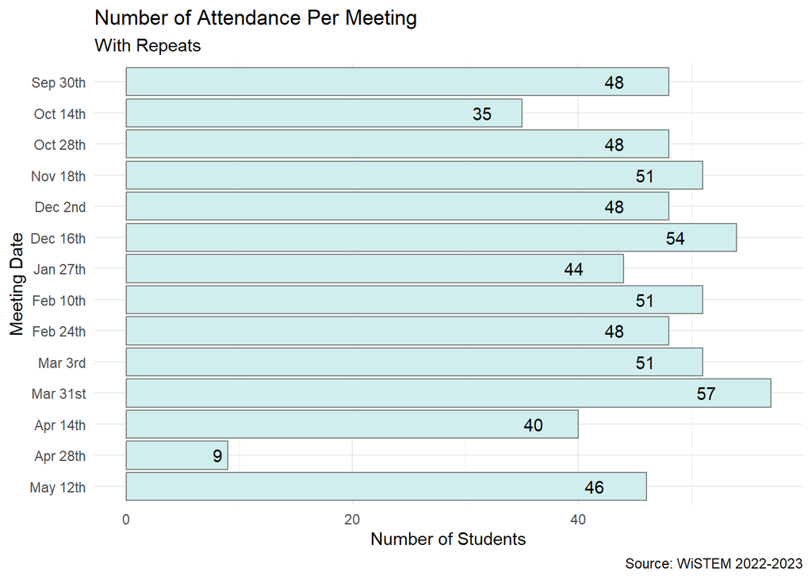

**Table for Attendance Per Meeting**

Number of Attendance Per Meeting

| date | num_students | proportion | percent |
| --- | --- | --- | --- |
| May 12th | 46 | 0.0730159 | 7.301587 |
| Apr 28th | 9 | 0.0142857 | 1.428571 |
| Apr 14th | 40 | 0.0634921 | 6.349206 |
| Mar 31st | 57 | 0.0904762 | 9.047619 |
| Mar 3rd | 51 | 0.0809524 | 8.095238 |
| Feb 24th | 48 | 0.0761905 | 7.619048 |
| Feb 10th | 51 | 0.0809524 | 8.095238 |
| Jan 27th | 44 | 0.0698413 | 6.984127 |
| Dec 16th | 54 | 0.0857143 | 8.571429 |
| Dec 2nd | 48 | 0.0761905 | 7.619048 |
| Nov 18th | 51 | 0.0809524 | 8.095238 |
| Oct 28th | 48 | 0.0761905 | 7.619048 |
| Oct 14th | 35 | 0.0555556 | 5.555556 |
| Sep 30th | 48 | 0.0761905 | 7.619048 |

## Attendance Per Month

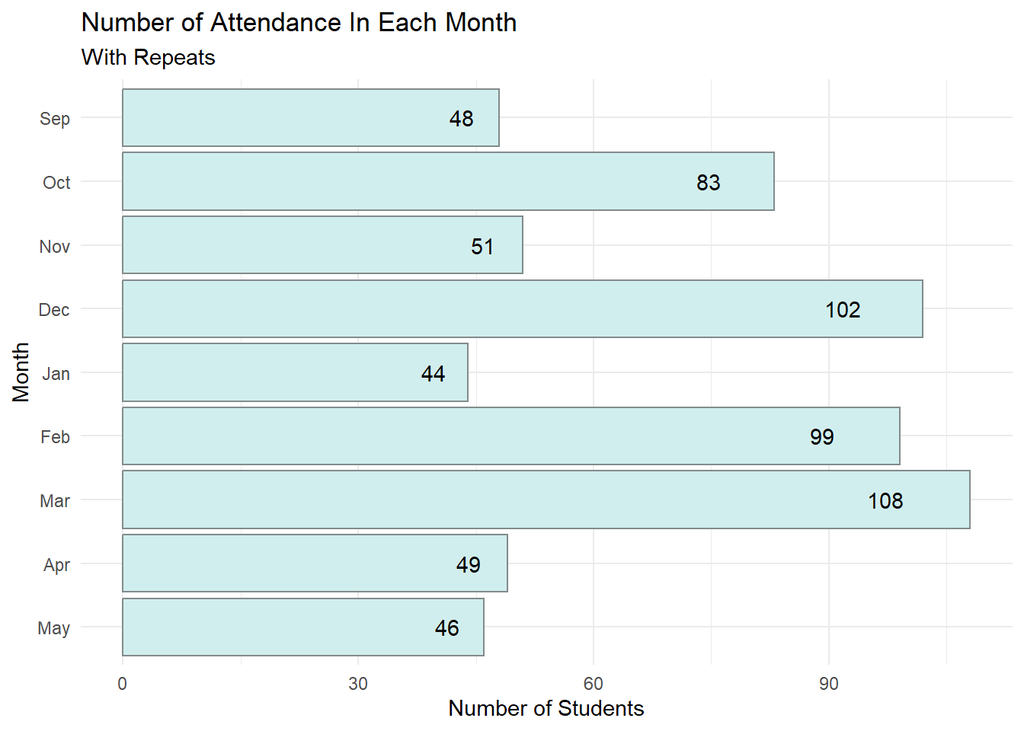

**Table for Attendance Per Month**

Number of Attedance In Each Month

| month | num_students | proportion | percent |
| --- | --- | --- | --- |
| May | 46 | 0.0730159 | 7.301587 |
| Apr | 49 | 0.0777778 | 7.777778 |
| Mar | 108 | 0.1714286 | 17.142857 |
| Feb | 99 | 0.1571429 | 15.714286 |
| Jan | 44 | 0.0698413 | 6.984127 |
| Dec | 102 | 0.1619048 | 16.190476 |
| Nov | 51 | 0.0809524 | 8.095238 |
| Oct | 83 | 0.1317460 | 13.174603 |
| Sep | 48 | 0.0761905 | 7.619048 |

## Attendance Per Topic

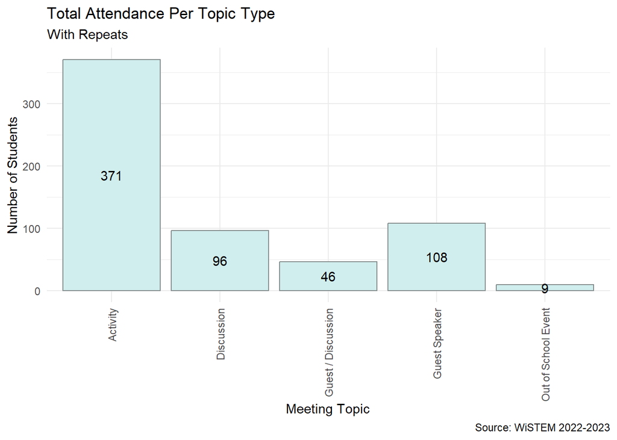

**Table for Attendance Per Topic**

Total Attendance Per Topic Type

| topic | total | proportion | percent |
| --- | --- | --- | --- |
| Activity | 371 | 0.5888889 | 58.888889 |
| Discussion | 96 | 0.1523810 | 15.238095 |
| Guest / Discussion | 46 | 0.0730159 | 7.301587 |
| Guest Speaker | 108 | 0.1714286 | 17.142857 |
| Out of School Event | 9 | 0.0142857 | 1.428571 |

## Average Attendance Per Topic

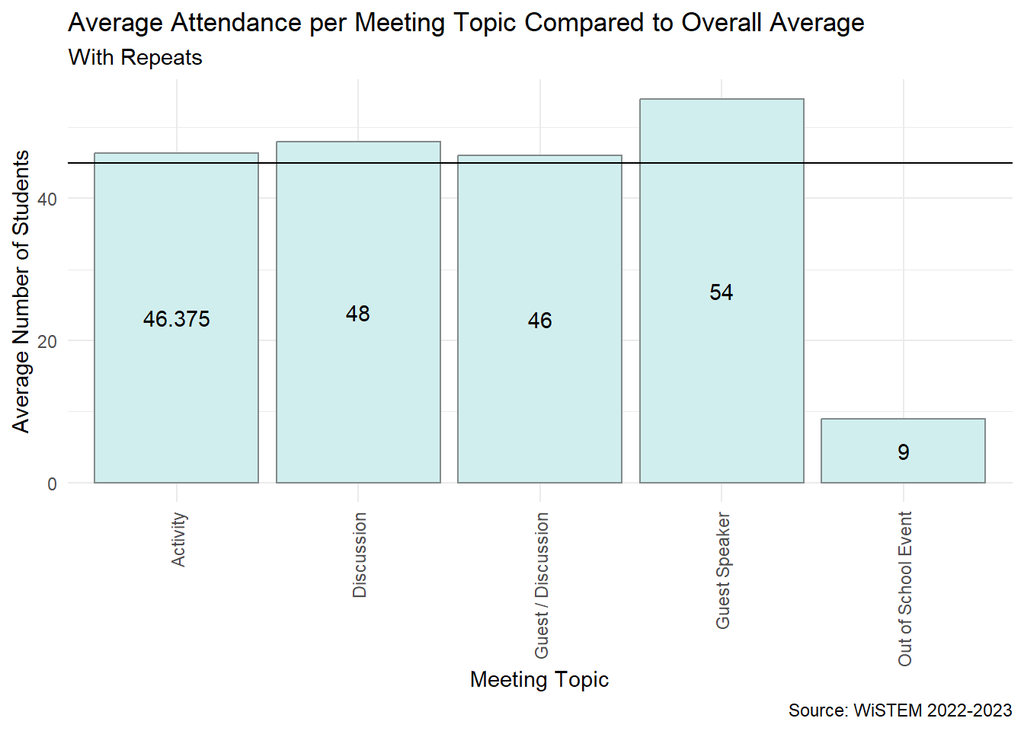

**Table for Average Attendance Per Topic**

Average Attendance Per Meeting Topic

| topic | meeting_count | total | meeting_avg | total_avg | benchmark |
| --- | --- | --- | --- | --- | --- |
| Activity | 8 | 371 | 46.375 | 45 | yes |
| Discussion | 2 | 96 | 48.000 | 45 | yes |
| Guest / Discussion | 1 | 46 | 46.000 | 45 | yes |
| Guest Speaker | 2 | 108 | 54.000 | 45 | yes |
| Out of School Event | 1 | 9 | 9.000 | 45 | no |

# Individual Attendance

## Number of Meetings Attended

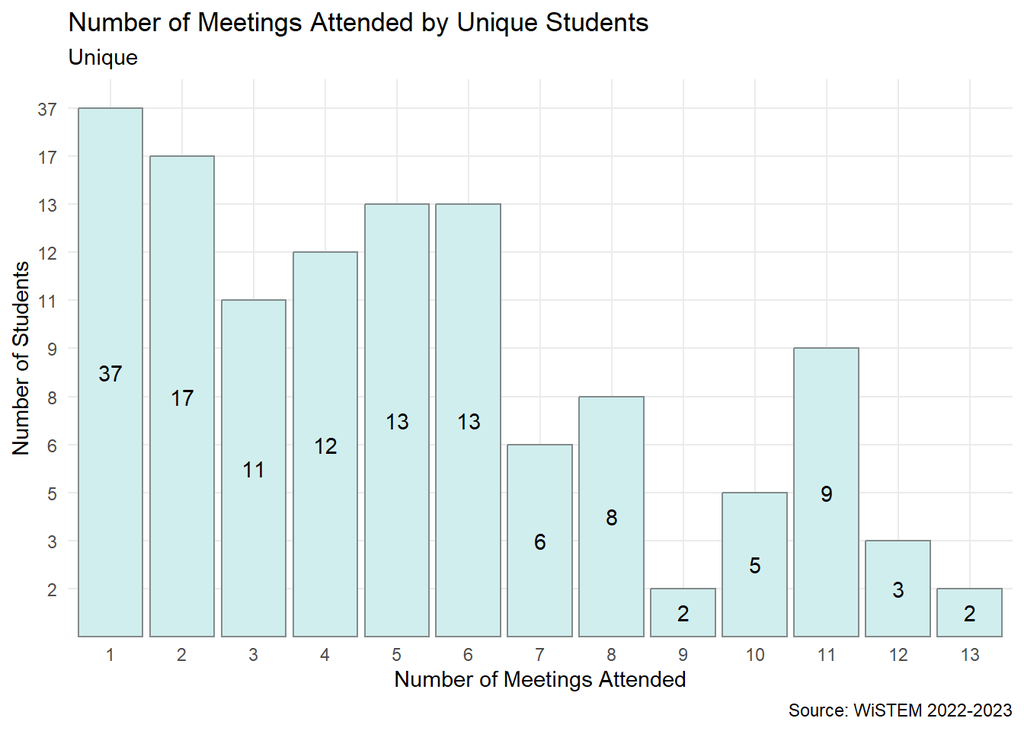

Summary of Number of Meetings Attended

| min | median | mean | std_dev | max | range |
| --- | --- | --- | --- | --- | --- |
| 1 | 4 | 4.565217 | 3.459793 | 13 | 12 |

**Table for Number of Meetings Attended**

Number of Meetings Attended by Unique Students

| num_meetings | num_students | proportion | percent |
| --- | --- | --- | --- |
| 1 | 37 | 0.2681159 | 26.811594 |
| 2 | 17 | 0.1231884 | 12.318841 |
| 5 | 13 | 0.0942029 | 9.420290 |
| 6 | 13 | 0.0942029 | 9.420290 |
| 4 | 12 | 0.0869565 | 8.695652 |
| 3 | 11 | 0.0797101 | 7.971014 |
| 11 | 9 | 0.0652174 | 6.521739 |
| 8 | 8 | 0.0579710 | 5.797101 |
| 7 | 6 | 0.0434783 | 4.347826 |
| 10 | 5 | 0.0362319 | 3.623188 |
| 12 | 3 | 0.0217391 | 2.173913 |
| 9 | 2 | 0.0144928 | 1.449275 |
| 13 | 2 | 0.0144928 | 1.449275 |

## Only One Meeting Attended

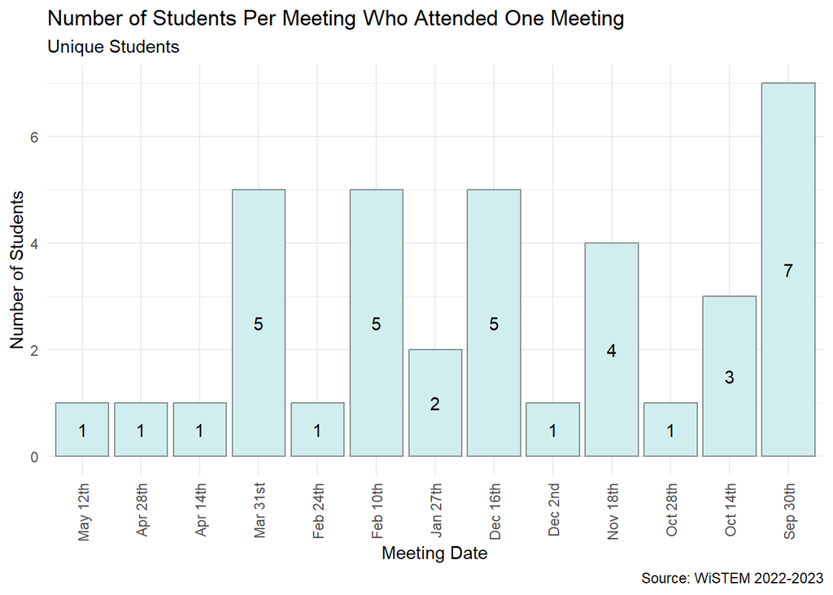

**Table for Only One Meeting Attended**

Number of Student Per Meetings Who Only Attended Once

| date | num_students | prop | percent |
| --- | --- | --- | --- |
| May 12th | 1 | 0.0270270 | 2.702703 |
| Apr 28th | 1 | 0.0270270 | 2.702703 |
| Apr 14th | 1 | 0.0270270 | 2.702703 |
| Mar 31st | 5 | 0.1351351 | 13.513514 |
| Feb 24th | 1 | 0.0270270 | 2.702703 |
| Feb 10th | 5 | 0.1351351 | 13.513514 |
| Jan 27th | 2 | 0.0540541 | 5.405405 |
| Dec 16th | 5 | 0.1351351 | 13.513514 |
| Dec 2nd | 1 | 0.0270270 | 2.702703 |
| Nov 18th | 4 | 0.1081081 | 10.810811 |
| Oct 28th | 1 | 0.0270270 | 2.702703 |
| Oct 14th | 3 | 0.0810811 | 8.108108 |
| Sep 30th | 7 | 0.1891892 | 18.918919 |

## One Meeting and Federal Race

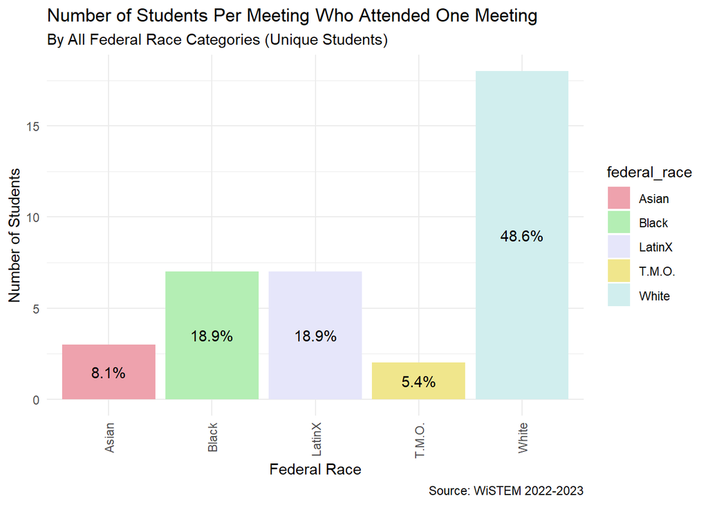

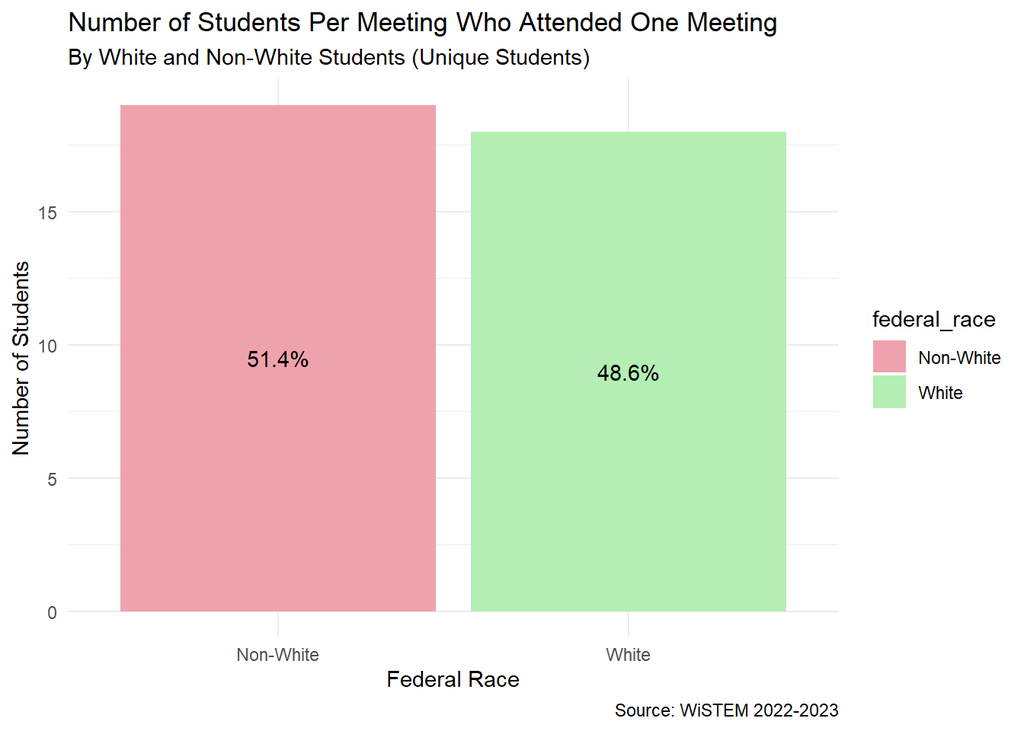

**Table for Federal Race and Only One Meeting Attended**

Federal Race and Students Who Attended One Meeting

| federal_race | num_students | prop | percent |
| --- | --- | --- | --- |
| Asian | 3 | 0.0810811 | 8.108108 |
| Black | 7 | 0.1891892 | 18.918919 |
| LatinX | 7 | 0.1891892 | 18.918919 |
| T.M.O. | 2 | 0.0540541 | 5.405405 |
| White | 18 | 0.4864865 | 48.648649 |

White & Non-White and Students Who Attended One Meeting

| federal_race | num_students | prop | percent |
| --- | --- | --- | --- |
| Non-White | 19 | 0.5135135 | 51.35135 |
| White | 18 | 0.4864865 | 48.64865 |

## One Meeting and Graduation Year

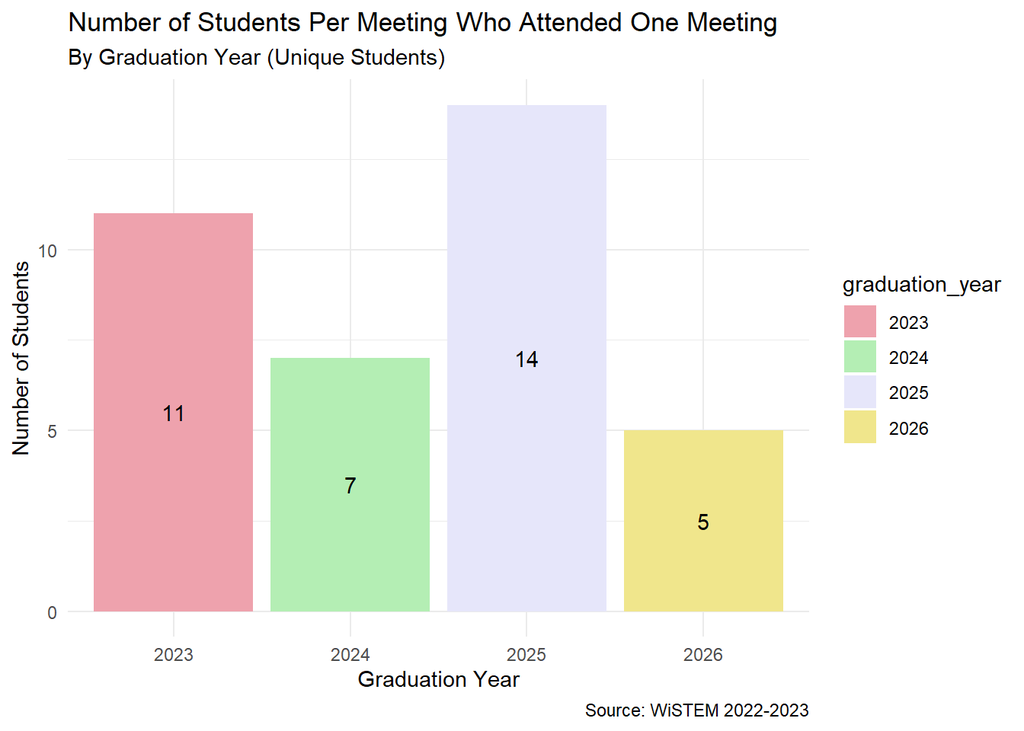

**Table for Graduation Year and Only One Meeting Attended**

Graduation Year and Students Who Attended One Meeting

| graduation_year | num_students | prop | percent |
| --- | --- | --- | --- |
| 2023 | 11 | 0.2972973 | 29.72973 |
| 2024 | 7 | 0.1891892 | 18.91892 |
| 2025 | 14 | 0.3783784 | 37.83784 |
| 2026 | 5 | 0.1351351 | 13.51351 |

## One Meeting and Topic

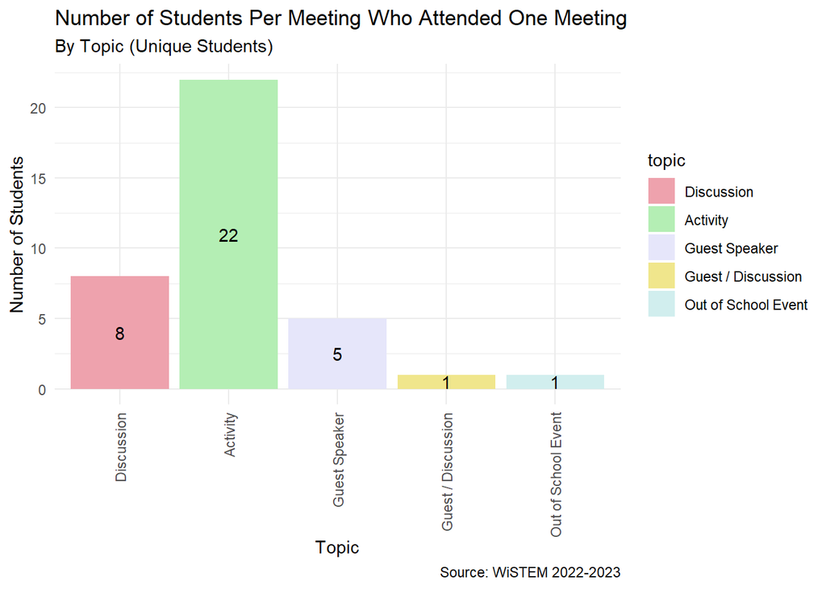

**Table for Topic and Only One Meeting Attended**

Topic and Students Who Attended One Meeting

[output not shown]

# Distribution Per Meeting

## September 30, 2022

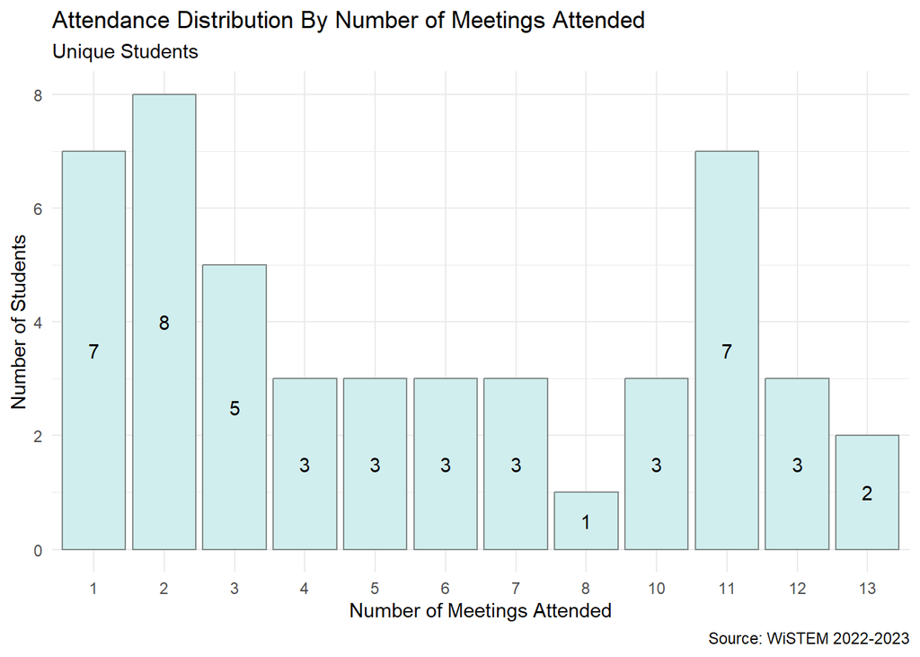

**Table for Number of Meetings Attended for September 30th**

Attendance Distribution By Number of Meetings Attended

| num_meetings | num_students | prop | percent |
| --- | --- | --- | --- |
| 1 | 7 | 0.1458333 | 14.583333 |
| 2 | 8 | 0.1666667 | 16.666667 |
| 3 | 5 | 0.1041667 | 10.416667 |
| 4 | 3 | 0.0625000 | 6.250000 |
| 5 | 3 | 0.0625000 | 6.250000 |
| 6 | 3 | 0.0625000 | 6.250000 |
| 7 | 3 | 0.0625000 | 6.250000 |
| 8 | 1 | 0.0208333 | 2.083333 |
| 10 | 3 | 0.0625000 | 6.250000 |
| 11 | 7 | 0.1458333 | 14.583333 |
| 12 | 3 | 0.0625000 | 6.250000 |
| 13 | 2 | 0.0416667 | 4.166667 |

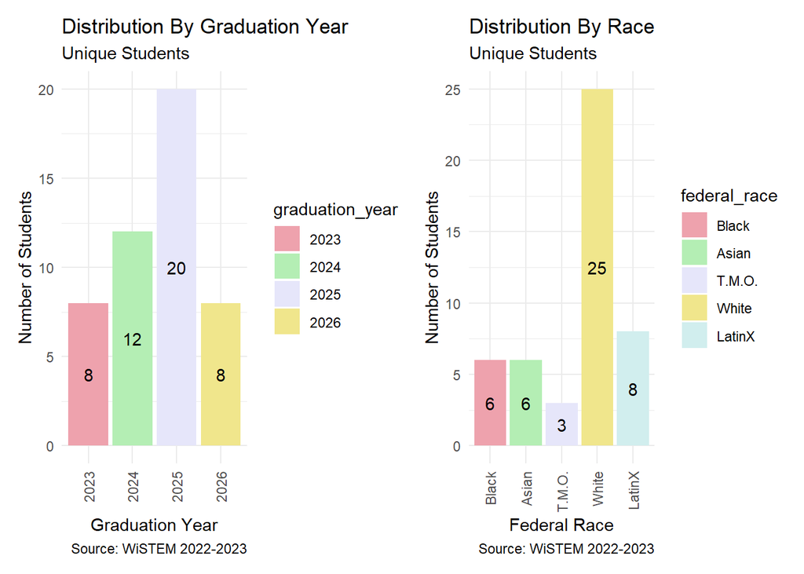

**Table for Graduation Race for September 30th**

Attendance Distribution By Graduation Year

| graduation_year | num_students | prop | percent |
| --- | --- | --- | --- |
| 2023 | 8 | 0.1666667 | 16.66667 |
| 2024 | 12 | 0.2500000 | 25.00000 |
| 2025 | 20 | 0.4166667 | 41.66667 |
| 2026 | 8 | 0.1666667 | 16.66667 |

**Table for Federal Race for September 30th**

Distribution By Federal Race

| federal_race | num_students | prop | percent |
| --- | --- | --- | --- |
| Black | 6 | 0.1250000 | 12.50000 |
| Asian | 6 | 0.1250000 | 12.50000 |
| T.M.O. | 3 | 0.0625000 | 6.25000 |
| White | 25 | 0.5208333 | 52.08333 |
| LatinX | 8 | 0.1666667 | 16.66667 |

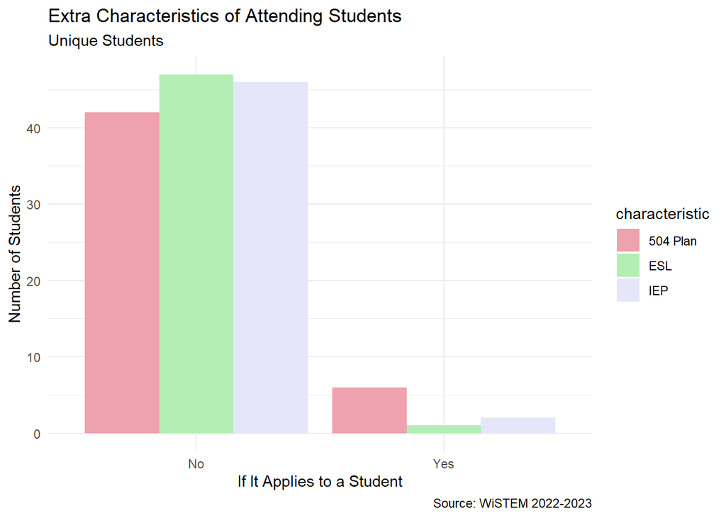

**Table for Additional Characteristics for September 30th**

Attendance Distribution by Additional Characteristics

| characteristic | applicable | num_students | prop | percent |
| --- | --- | --- | --- | --- |
| IEP | Yes | 2 | 0.0138889 | 1.3888889 |
| IEP | No | 46 | 0.3194444 | 31.9444444 |
| 504 Plan | Yes | 6 | 0.0416667 | 4.1666667 |
| 504 Plan | No | 42 | 0.2916667 | 29.1666667 |
| ESL | Yes | 1 | 0.0069444 | 0.6944444 |
| ESL | No | 47 | 0.3263889 | 32.6388889 |

## October 14, 2022

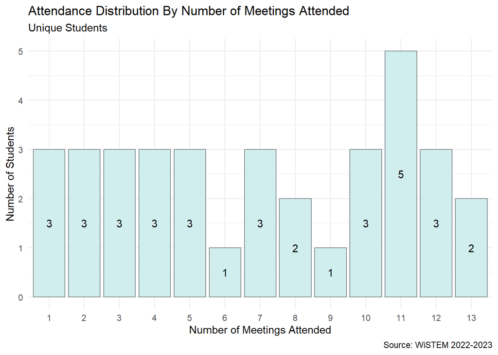

**Table for Number of Meetings Attended for October 14th**

Attendance Distribution By Number of Meetings Attended

| num_meetings | num_students | prop | percent |
| --- | --- | --- | --- |
| 1 | 3 | 0.0857143 | 8.571429 |
| 2 | 3 | 0.0857143 | 8.571429 |
| 3 | 3 | 0.0857143 | 8.571429 |
| 4 | 3 | 0.0857143 | 8.571429 |
| 5 | 3 | 0.0857143 | 8.571429 |
| 6 | 1 | 0.0285714 | 2.857143 |
| 7 | 3 | 0.0857143 | 8.571429 |
| 8 | 2 | 0.0571429 | 5.714286 |
| 9 | 1 | 0.0285714 | 2.857143 |
| 10 | 3 | 0.0857143 | 8.571429 |
| 11 | 5 | 0.1428571 | 14.285714 |
| 12 | 3 | 0.0857143 | 8.571429 |
| 13 | 2 | 0.0571429 | 5.714286 |

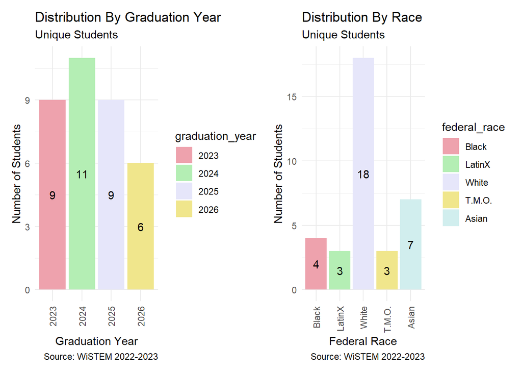

**Table for Graduation Race for October 14th**

Attendance Distribution By Graduation Year

| graduation_year | num_students | prop | percent |
| --- | --- | --- | --- |
| 2023 | 9 | 0.2571429 | 25.71429 |
| 2024 | 11 | 0.3142857 | 31.42857 |
| 2025 | 9 | 0.2571429 | 25.71429 |
| 2026 | 6 | 0.1714286 | 17.14286 |

**Table for Federal Race for October 14th**

Attendance Distribution By Federal Race

| federal_race | num_students | prop | percent |
| --- | --- | --- | --- |
| Black | 4 | 0.1142857 | 11.428571 |
| LatinX | 3 | 0.0857143 | 8.571429 |
| White | 18 | 0.5142857 | 51.428571 |
| T.M.O. | 3 | 0.0857143 | 8.571429 |
| Asian | 7 | 0.2000000 | 20.000000 |

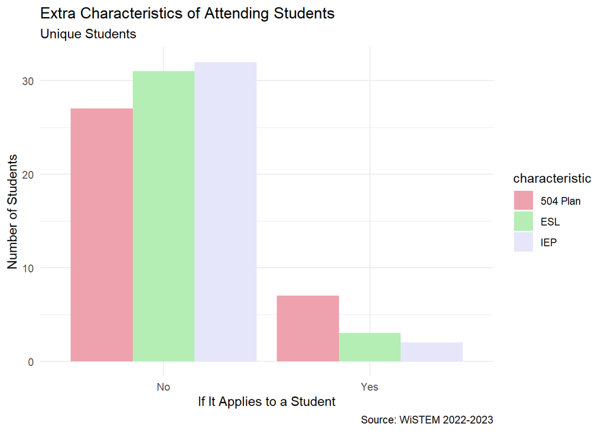

**Table for Additional Characteristics for October 14th**

Attendance Distribution by Additional Characteristics

| characteristic | applicable | num_students | prop | percent |
| --- | --- | --- | --- | --- |
| IEP | Yes | 2 | 0.0196078 | 1.960784 |
| IEP | No | 32 | 0.3137255 | 31.372549 |
| 504 Plan | Yes | 7 | 0.0686275 | 6.862745 |
| 504 Plan | No | 27 | 0.2647059 | 26.470588 |
| ESL | Yes | 3 | 0.0294118 | 2.941177 |
| ESL | No | 31 | 0.3039216 | 30.392157 |

## October 28, 2022

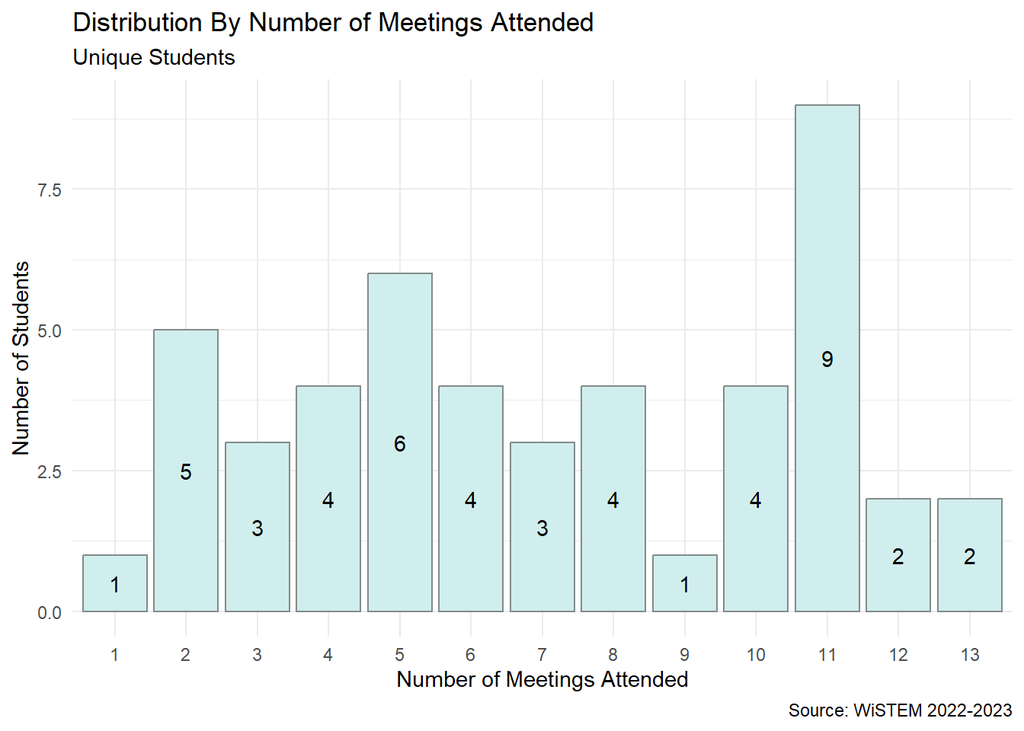

**Table for Number of Meetings Attended for October 28th**

Attendance Distribution By Number of Meetings Attended

| num_meetings | num_students | prop | percent |
| --- | --- | --- | --- |
| 1 | 1 | 0.0208333 | 2.083333 |
| 2 | 5 | 0.1041667 | 10.416667 |
| 3 | 3 | 0.0625000 | 6.250000 |
| 4 | 4 | 0.0833333 | 8.333333 |
| 5 | 6 | 0.1250000 | 12.500000 |
| 6 | 4 | 0.0833333 | 8.333333 |
| 7 | 3 | 0.0625000 | 6.250000 |
| 8 | 4 | 0.0833333 | 8.333333 |
| 9 | 1 | 0.0208333 | 2.083333 |
| 10 | 4 | 0.0833333 | 8.333333 |
| 11 | 9 | 0.1875000 | 18.750000 |
| 12 | 2 | 0.0416667 | 4.166667 |
| 13 | 2 | 0.0416667 | 4.166667 |

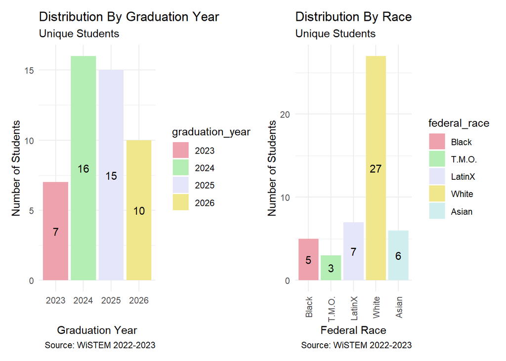

**Table for Graduation Race for October 28th**

Attendance Distribution By Graduation Year

| graduation_year | num_students | prop | percent |
| --- | --- | --- | --- |
| 2023 | 7 | 0.1458333 | 14.58333 |
| 2024 | 16 | 0.3333333 | 33.33333 |
| 2025 | 15 | 0.3125000 | 31.25000 |
| 2026 | 10 | 0.2083333 | 20.83333 |

**Table for Federal Race for October 28th**

Attendance Distribution By Federal Race

| federal_race | num_students | prop | percent |
| --- | --- | --- | --- |
| Black | 5 | 0.1041667 | 10.41667 |
| T.M.O. | 3 | 0.0625000 | 6.25000 |
| LatinX | 7 | 0.1458333 | 14.58333 |
| White | 27 | 0.5625000 | 56.25000 |
| Asian | 6 | 0.1250000 | 12.50000 |

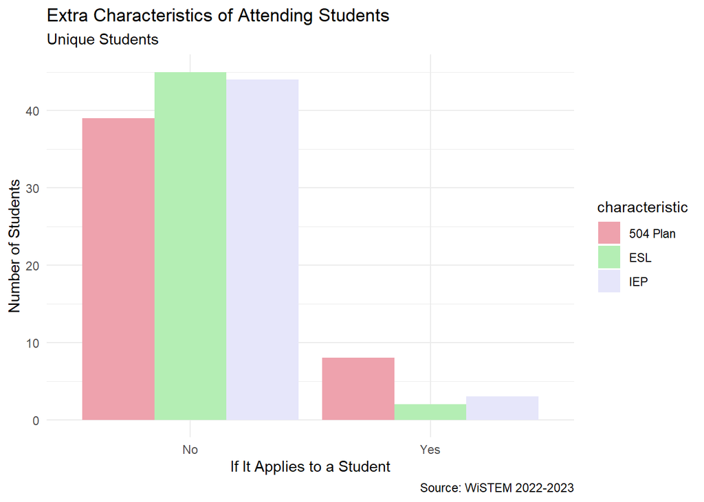

**Table for Additional Characteristics for October 28th**

Attendance Distribution by Additional Characteristics

| characteristic | applicable | num_students | prop | percent |
| --- | --- | --- | --- | --- |
| IEP | Yes | 3 | 0.0212766 | 2.127660 |
| IEP | No | 44 | 0.3120567 | 31.205674 |
| 504 Plan | Yes | 8 | 0.0567376 | 5.673759 |
| 504 Plan | No | 39 | 0.2765957 | 27.659575 |
| ESL | Yes | 2 | 0.0141844 | 1.418440 |
| ESL | No | 45 | 0.3191489 | 31.914894 |

## November 18, 2022

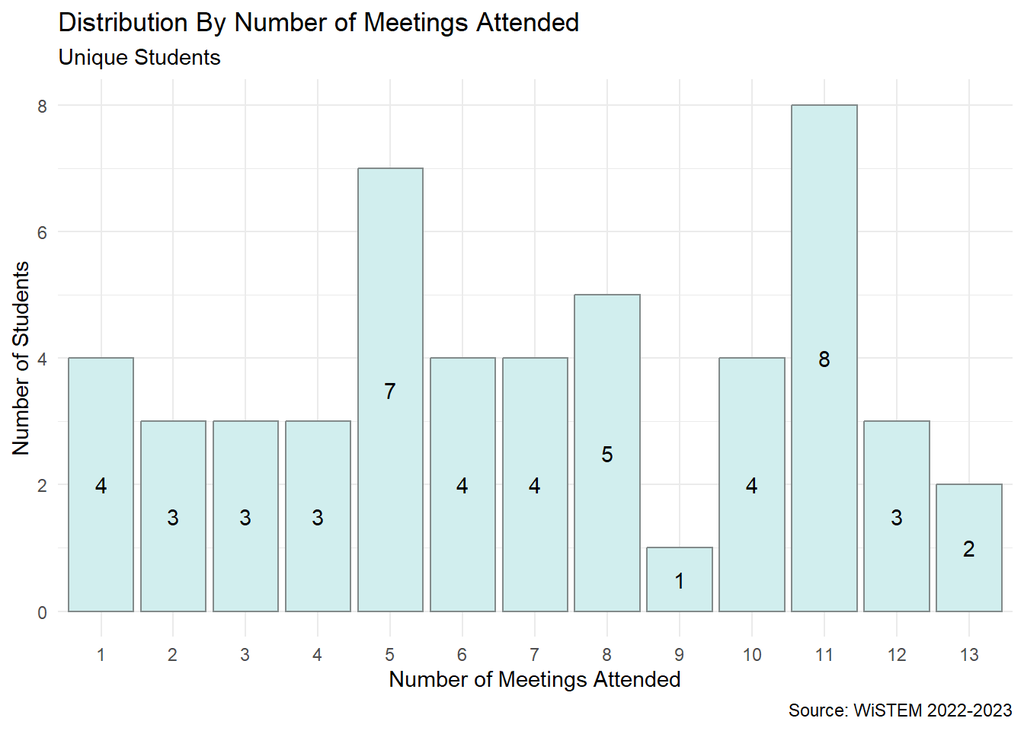

**Table for Number of Meetings Attended for November 18th**

Attendance Distribution By Number of Meetings Attended

| num_meetings | num_students | prop | percent |
| --- | --- | --- | --- |
| 1 | 4 | 0.0784314 | 7.843137 |
| 2 | 3 | 0.0588235 | 5.882353 |
| 3 | 3 | 0.0588235 | 5.882353 |
| 4 | 3 | 0.0588235 | 5.882353 |
| 5 | 7 | 0.1372549 | 13.725490 |
| 6 | 4 | 0.0784314 | 7.843137 |
| 7 | 4 | 0.0784314 | 7.843137 |
| 8 | 5 | 0.0980392 | 9.803922 |
| 9 | 1 | 0.0196078 | 1.960784 |
| 10 | 4 | 0.0784314 | 7.843137 |
| 11 | 8 | 0.1568627 | 15.686274 |
| 12 | 3 | 0.0588235 | 5.882353 |
| 13 | 2 | 0.0392157 | 3.921569 |

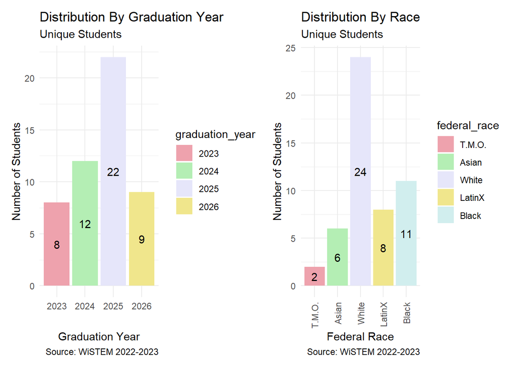

**Table for Graduation Race for November 18th**

Attendance Distribution By Graduation Year

| graduation_year | num_students | prop | percent |
| --- | --- | --- | --- |
| 2023 | 8 | 0.1568627 | 15.68627 |
| 2024 | 12 | 0.2352941 | 23.52941 |
| 2025 | 22 | 0.4313725 | 43.13725 |
| 2026 | 9 | 0.1764706 | 17.64706 |

**Table for Federal Race for November 18th**

Attendance Distribution By Federal Race

| federal_race | num_students | prop | percent |
| --- | --- | --- | --- |
| T.M.O. | 2 | 0.0392157 | 3.921569 |
| Asian | 6 | 0.1176471 | 11.764706 |
| White | 24 | 0.4705882 | 47.058824 |
| LatinX | 8 | 0.1568627 | 15.686274 |
| Black | 11 | 0.2156863 | 21.568628 |

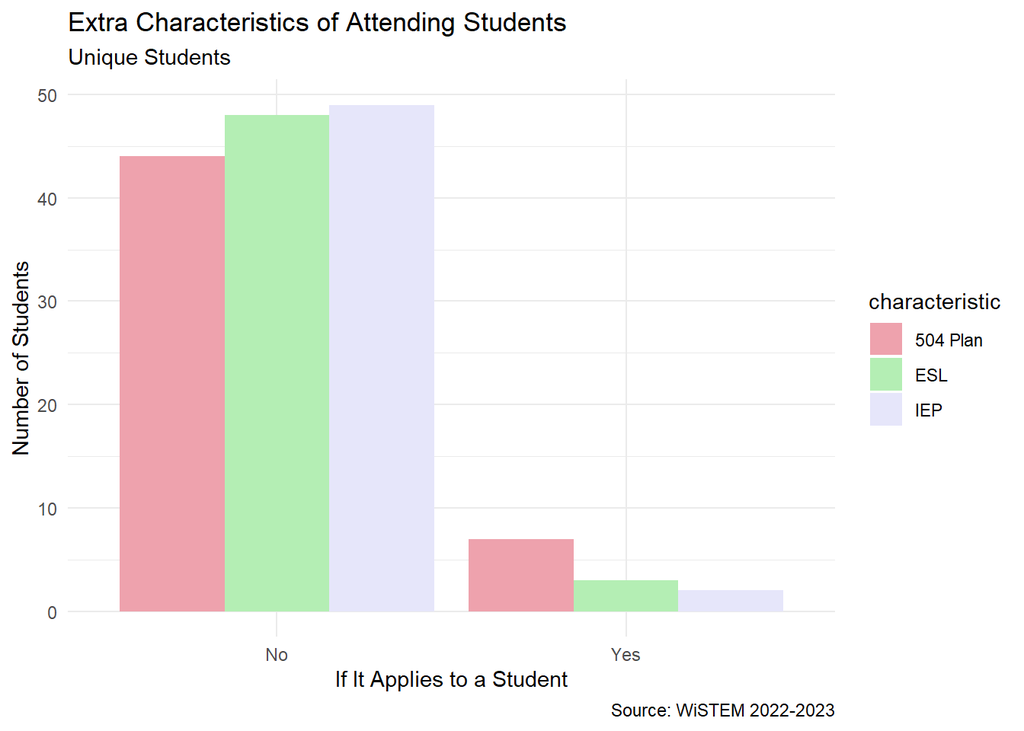

**Table for Additional Characteristics for Novmber 18th**

Attendance Distribution by Additional Characteristics

| characteristic | applicable | num_students | prop | percent |
| --- | --- | --- | --- | --- |
| IEP | Yes | 2 | 0.0130719 | 1.307190 |
| IEP | No | 49 | 0.3202614 | 32.026144 |
| 504 Plan | Yes | 7 | 0.0457516 | 4.575163 |
| 504 Plan | No | 44 | 0.2875817 | 28.758170 |
| ESL | Yes | 3 | 0.0196078 | 1.960784 |
| ESL | No | 48 | 0.3137255 | 31.372549 |

## December 2, 2022

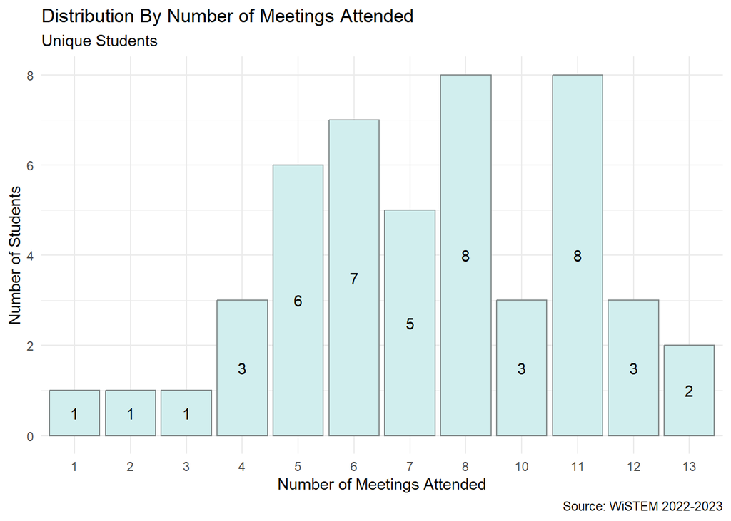

**Table for Number of Meetings Attended for December 2nd**

Attendance Distribution By Number of Meetings Attended

| num_meetings | num_students | prop | percent |
| --- | --- | --- | --- |
| 1 | 1 | 0.0208333 | 2.083333 |
| 2 | 1 | 0.0208333 | 2.083333 |
| 3 | 1 | 0.0208333 | 2.083333 |
| 4 | 3 | 0.0625000 | 6.250000 |
| 5 | 6 | 0.1250000 | 12.500000 |
| 6 | 7 | 0.1458333 | 14.583333 |
| 7 | 5 | 0.1041667 | 10.416667 |
| 8 | 8 | 0.1666667 | 16.666667 |
| 10 | 3 | 0.0625000 | 6.250000 |
| 11 | 8 | 0.1666667 | 16.666667 |
| 12 | 3 | 0.0625000 | 6.250000 |
| 13 | 2 | 0.0416667 | 4.166667 |

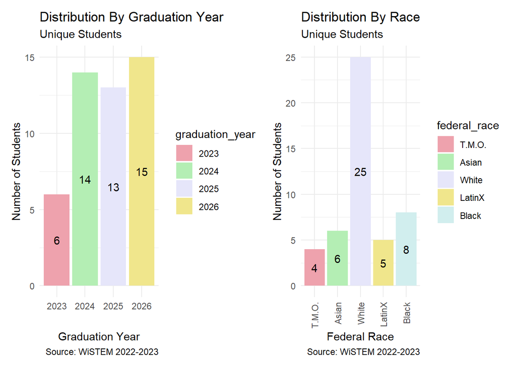

**Table for Graduation Race for December 2nd**

Attendance Distribution By Graduation Year

| graduation_year | num_students | prop | percent |
| --- | --- | --- | --- |
| 2023 | 6 | 0.1250000 | 12.50000 |
| 2024 | 14 | 0.2916667 | 29.16667 |
| 2025 | 13 | 0.2708333 | 27.08333 |
| 2026 | 15 | 0.3125000 | 31.25000 |

**Table for Federal Race for December 2nd**

Attendance Distribution By Federal Race

| federal_race | num_students | prop | percent |
| --- | --- | --- | --- |
| T.M.O. | 4 | 0.0833333 | 8.333333 |
| Asian | 6 | 0.1250000 | 12.500000 |
| White | 25 | 0.5208333 | 52.083333 |
| LatinX | 5 | 0.1041667 | 10.416667 |
| Black | 8 | 0.1666667 | 16.666667 |

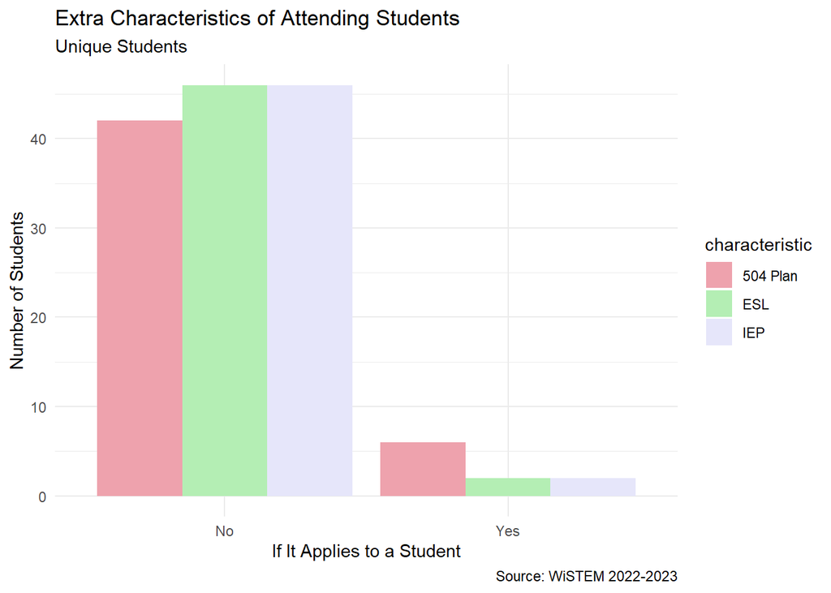

**Table for Additional Characteristics for December 2nd**

Attendance Distribution by Additional Characteristics

| characteristic | applicable | num_students | prop | percent |
| --- | --- | --- | --- | --- |
| IEP | Yes | 2 | 0.0138889 | 1.388889 |
| IEP | No | 46 | 0.3194444 | 31.944444 |
| 504 Plan | Yes | 6 | 0.0416667 | 4.166667 |
| 504 Plan | No | 42 | 0.2916667 | 29.166667 |
| ESL | Yes | 2 | 0.0138889 | 1.388889 |
| ESL | No | 46 | 0.3194444 | 31.944444 |

## January 27, 2023

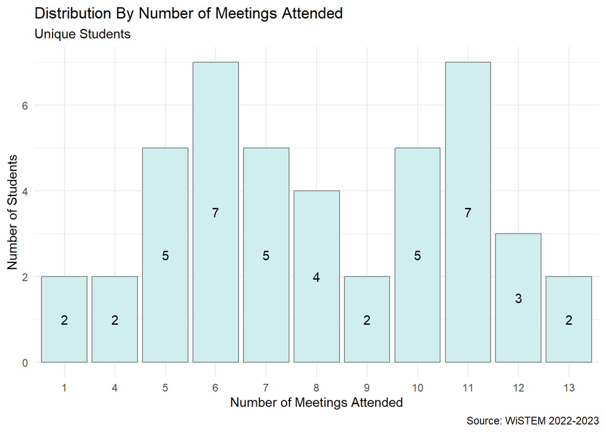

**Table for Number of Meetings Attended for January 27th**

Attendance Distribution By Number of Meetings Attended

| num_meetings | num_students | prop | percent |
| --- | --- | --- | --- |
| 1 | 2 | 0.0454545 | 4.545454 |
| 4 | 2 | 0.0454545 | 4.545454 |
| 5 | 5 | 0.1136364 | 11.363636 |
| 6 | 7 | 0.1590909 | 15.909091 |
| 7 | 5 | 0.1136364 | 11.363636 |
| 8 | 4 | 0.0909091 | 9.090909 |
| 9 | 2 | 0.0454545 | 4.545454 |
| 10 | 5 | 0.1136364 | 11.363636 |
| 11 | 7 | 0.1590909 | 15.909091 |
| 12 | 3 | 0.0681818 | 6.818182 |
| 13 | 2 | 0.0454545 | 4.545454 |

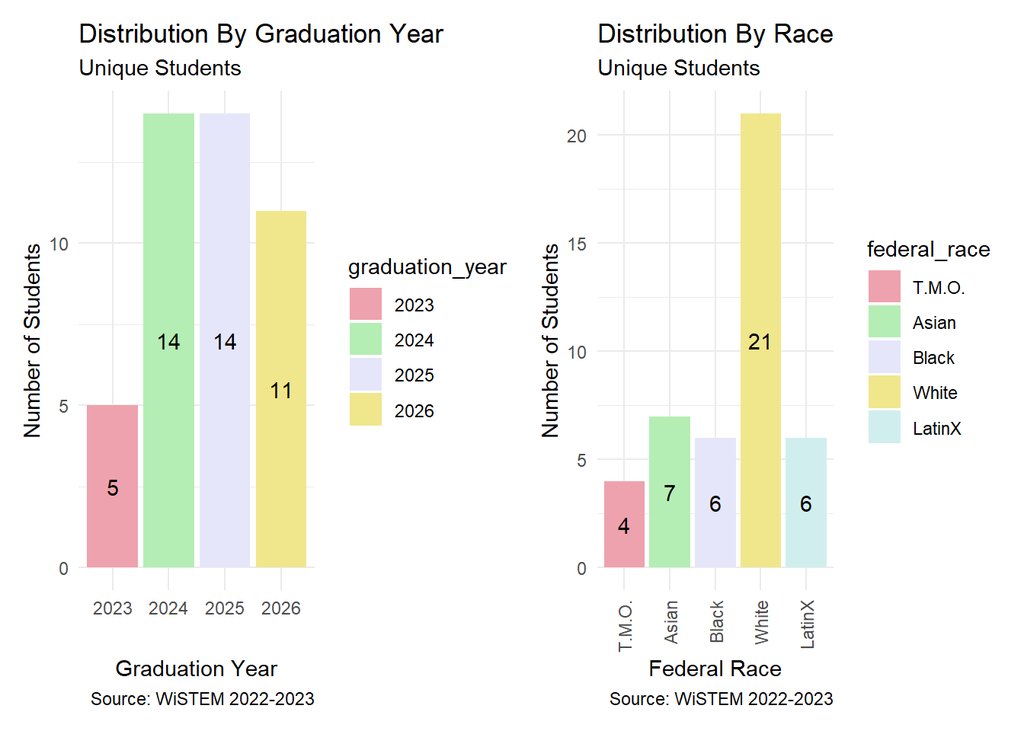

**Table for Graduation Race for January 27th**

Attendance Distribution By Graduation Year

| graduation_year | num_students | prop | percent |
| --- | --- | --- | --- |
| 2023 | 5 | 0.1136364 | 11.36364 |
| 2024 | 14 | 0.3181818 | 31.81818 |
| 2025 | 14 | 0.3181818 | 31.81818 |
| 2026 | 11 | 0.2500000 | 25.00000 |

**Table for Federal Race for January 27th**

Attendance Distribution By Federal Race

| federal_race | num_students | prop | percent |
| --- | --- | --- | --- |
| T.M.O. | 4 | 0.0909091 | 9.090909 |
| Asian | 7 | 0.1590909 | 15.909091 |
| Black | 6 | 0.1363636 | 13.636364 |
| White | 21 | 0.4772727 | 47.727273 |
| LatinX | 6 | 0.1363636 | 13.636364 |

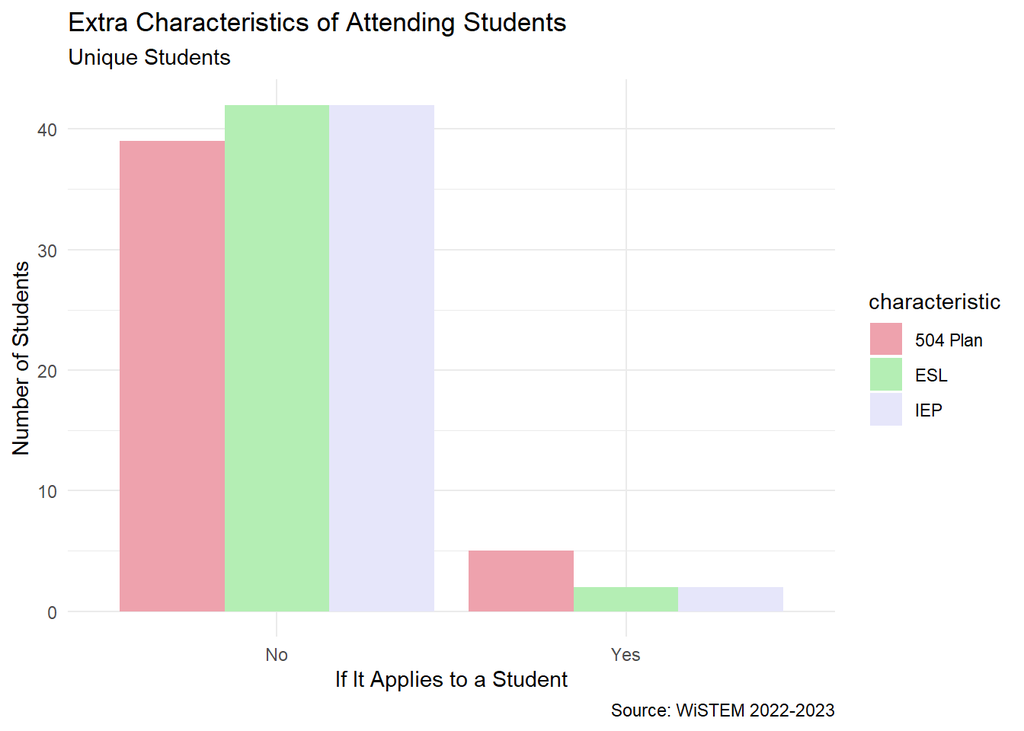

**Table for Additional Characteristics for January 27th**

Attendance Distribution by Additional Characteristics

| characteristic | applicable | num_students | prop | percent |
| --- | --- | --- | --- | --- |
| IEP | Yes | 2 | 0.0151515 | 1.515151 |
| IEP | No | 42 | 0.3181818 | 31.818182 |
| 504 Plan | Yes | 5 | 0.0378788 | 3.787879 |
| 504 Plan | No | 39 | 0.2954545 | 29.545455 |
| ESL | Yes | 2 | 0.0151515 | 1.515151 |
| ESL | No | 42 | 0.3181818 | 31.818182 |

## February 10, 2023

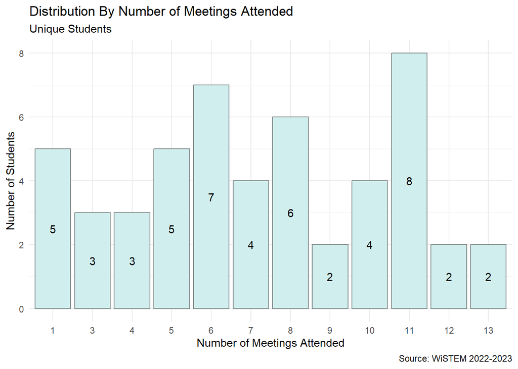

**Table for Number of Meetings Attended for February 10th**

Attendance Distribution By Number of Meetings Attended

| num_meetings | num_students | prop | percent |
| --- | --- | --- | --- |
| 1 | 5 | 0.0980392 | 9.803922 |
| 3 | 3 | 0.0588235 | 5.882353 |
| 4 | 3 | 0.0588235 | 5.882353 |
| 5 | 5 | 0.0980392 | 9.803922 |
| 6 | 7 | 0.1372549 | 13.725490 |
| 7 | 4 | 0.0784314 | 7.843137 |
| 8 | 6 | 0.1176471 | 11.764706 |
| 9 | 2 | 0.0392157 | 3.921569 |
| 10 | 4 | 0.0784314 | 7.843137 |
| 11 | 8 | 0.1568627 | 15.686274 |
| 12 | 2 | 0.0392157 | 3.921569 |
| 13 | 2 | 0.0392157 | 3.921569 |

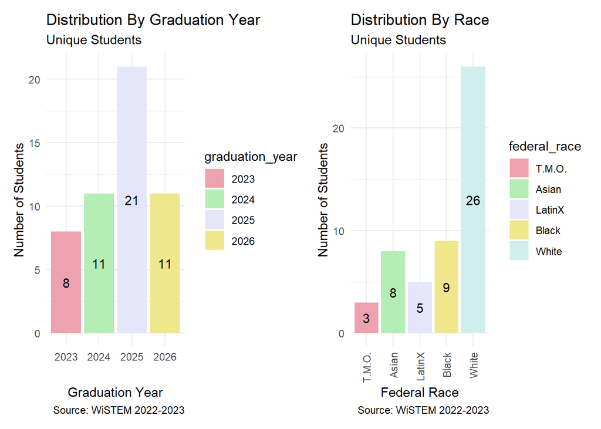

**Table for Graduation Race for February 10th**

Attendance Distribution By Graduation Year

| graduation_year | num_students | prop | percent |
| --- | --- | --- | --- |
| 2023 | 8 | 0.1568627 | 15.68627 |
| 2024 | 11 | 0.2156863 | 21.56863 |
| 2025 | 21 | 0.4117647 | 41.17647 |
| 2026 | 11 | 0.2156863 | 21.56863 |

**Table for Federal Race for February 10th**

Attendance Distribution By Federal Race

| federal_race | num_students | prop | percent |
| --- | --- | --- | --- |
| T.M.O. | 3 | 0.0588235 | 5.882353 |
| Asian | 8 | 0.1568627 | 15.686274 |
| LatinX | 5 | 0.0980392 | 9.803922 |
| Black | 9 | 0.1764706 | 17.647059 |
| White | 26 | 0.5098039 | 50.980392 |

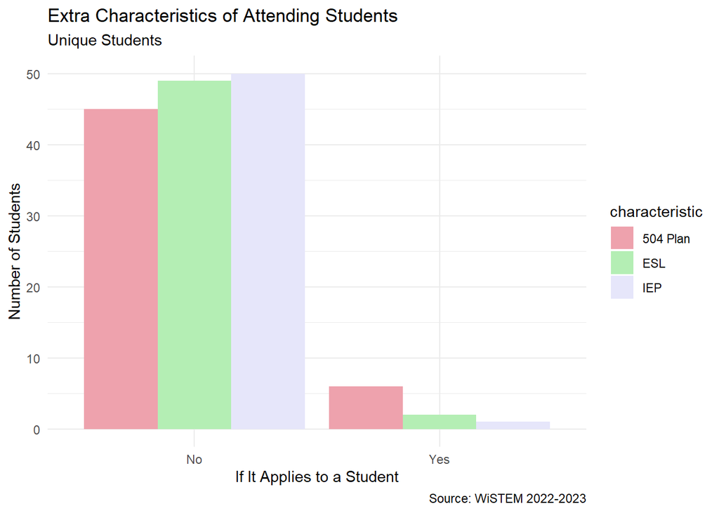

**Table for Additional Characteristics for February 10th**

Attendance Distribution by Additional Characteristics

| characteristic | applicable | num_students | prop | percent |
| --- | --- | --- | --- | --- |
| IEP | Yes | 1 | 0.0065359 | 0.6535948 |
| IEP | No | 50 | 0.3267974 | 32.6797386 |
| 504 Plan | Yes | 6 | 0.0392157 | 3.9215686 |
| 504 Plan | No | 45 | 0.2941176 | 29.4117647 |
| ESL | Yes | 2 | 0.0130719 | 1.3071895 |
| ESL | No | 49 | 0.3202614 | 32.0261438 |